# Predicting Student Grades

*Simon Wang*  
*CMSC320*  
*Updated: 12/16/22*

1. Introduction
2. Data
3. Exploration
   1. Study Time
   2. Extra Classes
   3. Past Failures
   4. Higher Education
   5. Correlation
4. Modeling
   1. Linear Regression
   2. Decision Tree
   3. Random Forest
   4. Support Vector Regression
5. Conclusion & Insights
6. Sources

## Introduction

Does how much a student studies affect their final grade? What about participating in extra curricular activities or going out  
with friends? There are many attributes of a student's life that may or may not affect their performance in school. Wouldn't  
you love to finally prove to your parents once and for all that your lack of studying isn't affecting your grades? Or maybe  
it does and your parents were right all along...

In this tutorial we will investigate how some of these attributes affect the final grade of a student. We use a dataset  
found in the UCL Machine Learning Repository curated by Paulo Cortez (see sources) which includes data from two Portugese  
secondary schools. The dataset features grades in two courses: Math and Portugese language. We will go into more depth about  
the various other attributes highlighted by this dataset including specific column names. Then, we will investigate which  
attributes might affect a student's grade and do some hypothesis testing and modelling to gain some insight about how  
a student can get that A!

[figure not shown]

## Data

First, we have to import our good old friend pandas (a python package) to help us load our data.

```python
import pandas as pd
```

```python
data = pd.read_csv('student-mat.csv')
```

Let's see what our data looks like!

```python
data.head()
```

|  | school | sex | age | address | famsize | Pstatus | Medu | Fedu | Mjob | Fjob | ... | famrel | freetime | goout | Dalc | Walc | health | absences | G1 | G2 | G3 |
| --- | --- | --- | --- | --- | --- | --- | --- | --- | --- | --- | --- | --- | --- | --- | --- | --- | --- | --- | --- | --- | --- |
| 0 | GP | F | 18 | U | GT3 | A | 4 | 4 | at_home | teacher | ... | 4 | 3 | 4 | 1 | 1 | 3 | 6 | 5 | 6 | 6 |
| 1 | GP | F | 17 | U | GT3 | T | 1 | 1 | at_home | other | ... | 5 | 3 | 3 | 1 | 1 | 3 | 4 | 5 | 5 | 6 |
| 2 | GP | F | 15 | U | LE3 | T | 1 | 1 | at_home | other | ... | 4 | 3 | 2 | 2 | 3 | 3 | 10 | 7 | 8 | 10 |
| 3 | GP | F | 15 | U | GT3 | T | 4 | 2 | health | services | ... | 3 | 2 | 2 | 1 | 1 | 5 | 2 | 15 | 14 | 15 |
| 4 | GP | F | 16 | U | GT3 | T | 3 | 3 | other | other | ... | 4 | 3 | 2 | 1 | 2 | 5 | 4 | 6 | 10 | 10 |

5 rows × 33 columns

```python
data.shape
```

```
(395, 33)
```

As you can see above, we now have a better idea of what the entries in our dataset look like. Each row represents  
one student our of 395 total, and there are 33 columns describing various attributes for each student.

Next we'll take a closer look at what types of columns we have in our dataset.

```python
data.columns
```

```
Index(['school', 'sex', 'age', 'address', 'famsize', 'Pstatus', 'Medu', 'Fedu',
       'Mjob', 'Fjob', 'reason', 'guardian', 'traveltime', 'studytime',
       'failures', 'schoolsup', 'famsup', 'paid', 'activities', 'nursery',
       'higher', 'internet', 'romantic', 'famrel', 'freetime', 'goout', 'Dalc',
       'Walc', 'health', 'absences', 'G1', 'G2', 'G3'],
      dtype='object')
```

From Kaggle.com, where I initially found this dataset, we have the following descriptions for each column:

**Attribute Information:**

- school - student's school (binary: 'GP' - Gabriel Pereira or 'MS' - Mousinho da Silveira)
- sex - student's sex (binary: 'F' - female or 'M' - male)
- age - student's age (numeric: from 15 to 22)
- address - student's home address type (binary: 'U' - urban or 'R' - rural)
- famsize - family size (binary: 'LE3' - less or equal to 3 or 'GT3' - greater than 3)
- Pstatus - parent's cohabitation status (binary: 'T' - living together or 'A' - apart)
- Medu - mother's education (numeric: 0 - none, 1 - primary education (4th grade), 2 - 5th to 9th grade, 3 - secondary education or 4 - higher education)
- Fedu - father's education (numeric: 0 - none, 1 - primary education (4th grade), 2 - 5th to 9th grade, 3 - secondary education or 4 - higher education)
- Mjob - mother's job (nominal: 'teacher', 'health' care related, civil 'services' (e.g. administrative or police), 'at_home' or 'other')
- Fjob - father's job (nominal: 'teacher', 'health' care related, civil 'services' (e.g. administrative or police), 'at_home' or 'other')
- reason - reason to choose this school (nominal: close to 'home', school 'reputation', 'course' preference or 'other')
- guardian - student's guardian (nominal: 'mother', 'father' or 'other')
- traveltime - home to school travel time (numeric: 1 - <15 min., 2 - 15 to 30 min., 3 - 30 min. to 1 hour, or 4 - >1 hour)
- studytime - weekly study time (numeric: 1 - <2 hours, 2 - 2 to 5 hours, 3 - 5 to 10 hours, or 4 - >10 hours)
- failures - number of past class failures (numeric: n if 1<=n<3, else 4)
- schoolsup - extra educational support (binary: yes or no)
- famsup - family educational support (binary: yes or no)
- paid - extra paid classes within the course subject (Math or Portuguese) (binary: yes or no)
- activities - extra-curricular activities (binary: yes or no)
- nursery - attended nursery school (binary: yes or no)
- higher - wants to take higher education (binary: yes or no)
- internet - Internet access at home (binary: yes or no)
- romantic - with a romantic relationship (binary: yes or no)
- famrel - quality of family relationships (numeric: from 1 - very bad to 5 - excellent)
- freetime - free time after school (numeric: from 1 - very low to 5 - very high)
- goout - going out with friends (numeric: from 1 - very low to 5 - very high)
- Dalc - workday alcohol consumption (numeric: from 1 - very low to 5 - very high)
- Walc - weekend alcohol consumption (numeric: from 1 - very low to 5 - very high)
- health - current health status (numeric: from 1 - very bad to 5 - very good)
- absences - number of school absences (numeric: from 0 to 93)

Grades are related with the course subject, Math or Portuguese:

G1 - first period grade (numeric: from 0 to 20)  
G2 - second period grade (numeric: from 0 to 20)  
G3 - final grade (numeric: from 0 to 20, output target)

Next, we check if there are any missing values.

```python
data.isnull().any()
```

```
school        False
sex           False
age           False
address       False
famsize       False
Pstatus       False
Medu          False
Fedu          False
Mjob          False
Fjob          False
reason        False
guardian      False
traveltime    False
studytime     False
failures      False
schoolsup     False
famsup        False
paid          False
activities    False
nursery       False
higher        False
internet      False
romantic      False
famrel        False
freetime      False
goout         False
Dalc          False
Walc          False
health        False
absences      False
G1            False
G2            False
G3            False
dtype: bool
```

Great, it seems like there is no missing data so we can safely continue!

## Exploration

Here's where the fun begins! Let's use some useful Python packages to visuallize some data and take a closer look at  
all of these interesting attributes. In this section we will do some basic analysis to so we can figure out which  
attributes might yield more interesting insights in our modelling and hypothesis testing later on. This, way, we don't waste  
too much time analyzing features that obviously won't give us very useful resorts. Plus, we get to learn more about our data  
and see pretty graphs too! :)

First, to make our analysis more straightforward let's look only at the final grades of the students, which is given  
by the G3 column as described in the column information above.

How are our students doing overall? Let's check out the overall distribution of final grades using pyplot.

```python
from matplotlib import pyplot as plt
import seaborn as sns
import numpy as np

final_grades = data['G3']
final_grades.describe()
```

```
count    395.000000
mean      10.415190
std        4.581443
min        0.000000
25%        8.000000
50%       11.000000
75%       14.000000
max       20.000000
Name: G3, dtype: float64
```

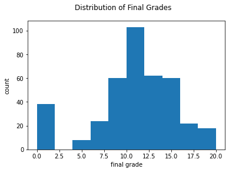

```python
fig = plt.figure()
plt.hist(final_grades)
plt.xlabel('final grade')
plt.ylabel('count')
fig.suptitle('Distribution of Final Grades')
```

```python
final_grades.value_counts()[0]
```

```
38
```

By creating a simple histogram of our data we can see that the final grades of the students are roughly normally distributed,  
although there are quite a few occurrences of zero scores as an outlier. Using the pandas value_counts function we can see  
that 38 unfortunate students received zeroes as a final grade. Let's investigate what happened with these students.

```python
# selecting rows with a final grade of zero from our data
zero_score = data[data['G3'] == 0]
zero_score.head()
```

|  | school | sex | age | address | famsize | Pstatus | Medu | Fedu | Mjob | Fjob | ... | famrel | freetime | goout | Dalc | Walc | health | absences | G1 | G2 | G3 |
| --- | --- | --- | --- | --- | --- | --- | --- | --- | --- | --- | --- | --- | --- | --- | --- | --- | --- | --- | --- | --- | --- |
| 128 | GP | M | 18 | R | GT3 | T | 2 | 2 | services | other | ... | 3 | 3 | 3 | 1 | 2 | 4 | 0 | 7 | 4 | 0 |
| 130 | GP | F | 15 | R | GT3 | T | 3 | 4 | services | teacher | ... | 4 | 2 | 2 | 2 | 2 | 5 | 0 | 12 | 0 | 0 |
| 131 | GP | F | 15 | U | GT3 | T | 1 | 1 | at_home | other | ... | 4 | 3 | 3 | 1 | 2 | 4 | 0 | 8 | 0 | 0 |
| 134 | GP | M | 15 | R | GT3 | T | 3 | 4 | at_home | teacher | ... | 5 | 3 | 3 | 1 | 1 | 5 | 0 | 9 | 0 | 0 |
| 135 | GP | F | 15 | U | GT3 | T | 4 | 4 | services | at_home | ... | 4 | 3 | 3 | 1 | 1 | 5 | 0 | 11 | 0 | 0 |

5 rows × 33 columns

```python
zero_score['G1'].describe()
```

```
count    38.000000
mean      7.526316
std       1.811925
min       4.000000
25%       6.000000
50%       7.000000
75%       9.000000
max      12.000000
Name: G1, dtype: float64
```

```python
zero_score['G2'].describe()
```

```
count    38.000000
mean      4.657895
std       3.700083
min       0.000000
25%       0.000000
50%       5.000000
75%       8.000000
max      10.000000
Name: G2, dtype: float64
```

Looking at the data for these students that received a zero for their final grade, we can notice that they have especially  
low first and second period grades. Maybe there is some minimum average score across the two periods for the student to  
pass overall? That would explain why even though they received grades for the first two periods they received a zero for the  
final. To figure investigate further, let's quickly check the average first and second period scores of the students that  
did not receive zeros.

```python
non_zero = data[data['G3'] != 0]
non_zero.head()
```

|  | school | sex | age | address | famsize | Pstatus | Medu | Fedu | Mjob | Fjob | ... | famrel | freetime | goout | Dalc | Walc | health | absences | G1 | G2 | G3 |
| --- | --- | --- | --- | --- | --- | --- | --- | --- | --- | --- | --- | --- | --- | --- | --- | --- | --- | --- | --- | --- | --- |
| 0 | GP | F | 18 | U | GT3 | A | 4 | 4 | at_home | teacher | ... | 4 | 3 | 4 | 1 | 1 | 3 | 6 | 5 | 6 | 6 |
| 1 | GP | F | 17 | U | GT3 | T | 1 | 1 | at_home | other | ... | 5 | 3 | 3 | 1 | 1 | 3 | 4 | 5 | 5 | 6 |
| 2 | GP | F | 15 | U | LE3 | T | 1 | 1 | at_home | other | ... | 4 | 3 | 2 | 2 | 3 | 3 | 10 | 7 | 8 | 10 |
| 3 | GP | F | 15 | U | GT3 | T | 4 | 2 | health | services | ... | 3 | 2 | 2 | 1 | 1 | 5 | 2 | 15 | 14 | 15 |
| 4 | GP | F | 16 | U | GT3 | T | 3 | 3 | other | other | ... | 4 | 3 | 2 | 1 | 2 | 5 | 4 | 6 | 10 | 10 |

5 rows × 33 columns

```python
non_zero['G1'].describe()
```

```
count    357.000000
mean      11.268908
std        3.240450
min        3.000000
25%        9.000000
50%       11.000000
75%       14.000000
max       19.000000
Name: G1, dtype: float64
```

```python
non_zero['G2'].describe()
```

```
count    357.000000
mean      11.358543
std        3.147188
min        5.000000
25%        9.000000
50%       11.000000
75%       14.000000
max       19.000000
Name: G2, dtype: float64
```

Now we can see a clear difference between the non-zero scores and the zero scores. The non-zero scoring students had average  
first and second period grades of around 11, while zero scoring students had averages of around 7 and 4 respectively. This  
supports our theory that there is a minimum grade across the two periods that students must achieve to pass the course. Now  
that we understand a bit about why this outlier could be present we can know how to deal with it better later!

Moving on, we'll take a look at a few specific attributes and see if they seem to have an effect on the final grades.

### Study Time

Right off the bat, one of the columns that stands out the most to me just by looking at the descriptions is study time.  
Just from intuition I would assume that students who study more will perform better (my mom definitely thinks so). Well, let's  
do some exploration to see if that's true!

```python
study_times = data['studytime']
study_times.describe()
```

```
count    395.000000
mean       2.035443
std        0.839240
min        1.000000
25%        1.000000
50%        2.000000
75%        2.000000
max        4.000000
Name: studytime, dtype: float64
```

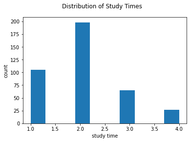

```python
fig = plt.figure()
plt.hist(study_times)
plt.xlabel('study time')
plt.ylabel('count')
fig.suptitle('Distribution of Study Times')
```

Using the histogram, we can see that most students had a study time of 2, which means they study 2-5 hours a week. Next, we'll  
look at the relationship between study time and final grade.

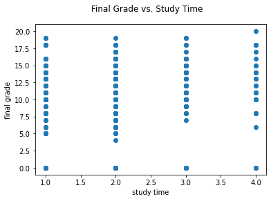

```python
fig = plt.figure()
plt.scatter(study_times, final_grades)
plt.xlabel('study time')
plt.ylabel('final grade')
fig.suptitle('Final Grade vs. Study Time')
```

This scatter plot doesn't give us much information about the distributions for each study time, so let's try a box plot.

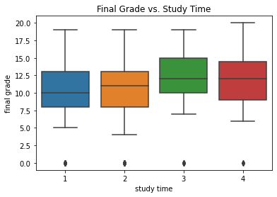

```python
b = sns.boxplot(x = study_times, y = final_grades)
b.axes.set_title('Final Grade vs. Study Time')
b.set_xlabel('study time')
b.set_ylabel('final grade')
plt.show()
```

Much better! In the box plots above we can see that the final grades of students do seem to rise as study time increases.  
However, at study time four (>10 hours), the final grades of students seemed to drop. I guess it might be a bad thing\ to study *too* much! We can use the same describe() function from earlier to get a closer look at the average grades for  
each study time group.

```python
# stats for students in the study time 1 group
data[data['studytime'] == 1]['G3'].describe()
```

```
count    105.000000
mean      10.047619
std        4.956311
min        0.000000
25%        8.000000
50%       10.000000
75%       13.000000
max       19.000000
Name: G3, dtype: float64
```

```python
# stats for students in the study time 2 group
data[data['studytime'] == 2]['G3'].describe()
```

```
count    198.000000
mean      10.171717
std        4.217537
min        0.000000
25%        8.000000
50%       11.000000
75%       13.000000
max       19.000000
Name: G3, dtype: float64
```

```python
# stats for students in the study time 3 group
data[data['studytime'] == 3]['G3'].describe()
```

```
count    65.000000
mean     11.400000
std       4.639504
min       0.000000
25%      10.000000
50%      12.000000
75%      15.000000
max      19.000000
Name: G3, dtype: float64
```

```python
# stats for students in the study time 4 group
data[data['studytime'] == 4]['G3'].describe()
```

```
count    27.000000
mean     11.259259
std       5.281263
min       0.000000
25%       9.000000
50%      12.000000
75%      14.500000
max      20.000000
Name: G3, dtype: float64
```

### Extra Classes

Do paid extra classes help students achieve better grades? The students and their parents that are paying for these classes  
would certainly hope so! Let's explore our data to get a better idea!

```python
data['paid'].head()
```

```
0     no
1     no
2    yes
3    yes
4    yes
Name: paid, dtype: object
```

We can see that the "paid" column contains binary values of "yes" or "no". Let's look at how mane students actually  
paid for extra classes.

```python
extra = data[data['paid'] == 'yes']
no_extra = data[data['paid'] == 'no']

print('# Students with paid extra classes: ', len(extra))
print('# Students without paid extra classes: ', len(no_extra))
```

```
# Students with paid extra classes:  181
# Students without paid extra classes:  214
```

The number of students with and without paid extra classes seems to be pretty even, so let's take a look at how this  
attribute affects their performance.

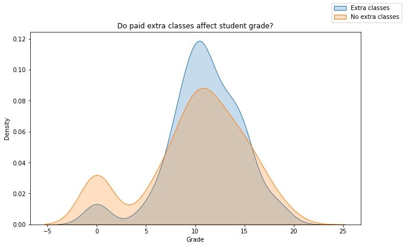

```python
fig = plt.figure(figsize=(10,6))
sns.kdeplot(extra['G3'], shade = True)
sns.kdeplot(no_extra['G3'], shade = True)
plt.title('Do paid extra classes affect student grade?')
plt.xlabel('Grade');
plt.ylabel('Density')
fig.legend(labels=['Extra classes','No extra classes'])
plt.show()
```

From the above plot, it appears that paid extra classes do actually improve student performance. The blue curve  
represents the grade distribution of students that paid for extra classes, and as we can see it has a higher density  
of grades at the average grade of around 10. And we can see by the small peak on the left side of the graph  
that these students received a grade of 0 less often as well.

### Past Failures

Are students that have failed classes in the past more likely to get worse grades? This would certainly be  
a common assumption to make, so let's take a look at our data to see if its true for these students!

```python
# what does the column look like?
data['failures'].head()
```

```
0    0
1    0
2    3
3    0
4    0
Name: failures, dtype: int64
```

```python
# looking at what range of values this column hase
display(np.unique(data['failures']))
```

```
array([0, 1, 2, 3])
```

Now that we have a better idea of what the "failures" column looks like, we can visualizing it!. Note hethat  
even though the data set description says there can be a value of 4 if the number of failures is >3, there are no  
students in our dataset with more than 4 failures as shown by the range we found above.

```python
# getting summary stats for the column
past_fails = data['failures']
past_fails.describe()
```

```
count    395.000000
mean       0.334177
std        0.743651
min        0.000000
25%        0.000000
50%        0.000000
75%        0.000000
max        3.000000
Name: failures, dtype: float64
```

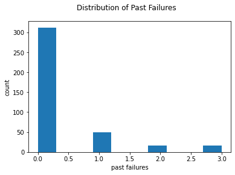

```python
fig = plt.figure()
plt.hist(past_fails)
plt.xlabel('past failures')
plt.ylabel('count')
fig.suptitle('Distribution of Past Failures')
```

```python
print('# Students who have never failed a class in the past:', len(data[data['failures'] == 0]))
```

```
# Students who have never failed a class in the past: 312
```

```python
print('# Students who have failed a class in the past:', 395 - 312)
```

```
# Students who have failed a class in the past: 83
```

```python
print('# Students who have failed a class 2 times or more in the past:', len(data[data['failures'] >= 2]))
```

```
# Students who have failed a class 2 times or more in the past: 33
```

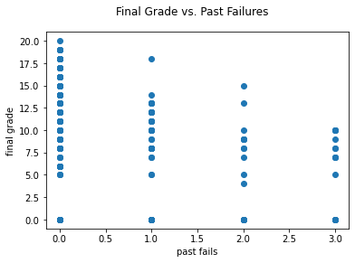

```python
fig = plt.figure()
plt.scatter(past_fails, final_grades)
plt.xlabel('past fails')
plt.ylabel('final grade')
fig.suptitle('Final Grade vs. Past Failures')
```

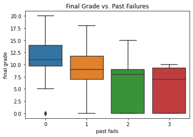

```python
b = sns.boxplot(x = past_fails, y = final_grades)
b.axes.set_title('Final Grade vs. Past Failures')
b.set_xlabel('past fails')
b.set_ylabel('final grade')
plt.show()
```

The trend here is quite clear even just from the scatter plot, however the box plot still shows it more clearly.  
The number of past failures seems to definitely affect the student's final grade, as the number increases the  
students final grade will tend to decrease.

### Higher Education

Does the drive to get into college help students get better grades? Let's explore the "higher" column, which indicates  
whether the student wants to take higher education or not.

```python
data['higher'].head()
```

```
0    yes
1    yes
2    yes
3    yes
4    yes
Name: higher, dtype: object
```

```python
display(np.unique(data['higher']))
```

```
array(['no', 'yes'], dtype=object)
```

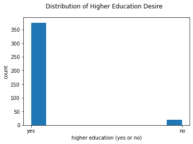

```python
high_ed = data['higher']

fig = plt.figure()
plt.hist(high_ed)
plt.xlabel('higher education (yes or no)')
plt.ylabel('count')
fig.suptitle('Distribution of Higher Education Desire')
```

Again, just like with past failures it seems the vast majority of our students intend to pursue higher education.  
Next let's find out how this affects their grades!

```python
# splitting data up based on if the student wants to pursue higher education or not
yes_higher = data[data['higher'] == 'yes']
no_higher = data[data['higher'] == 'no']
```

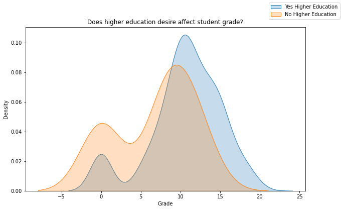

```python
fig = plt.figure(figsize=(10,6))
sns.kdeplot(yes_higher['G3'], shade = True)
sns.kdeplot(no_higher['G3'], shade = True)
plt.title('Does higher education desire affect student grade?')
plt.xlabel('Grade');
plt.ylabel('Density')
fig.legend(labels=['Yes Higher Education','No Higher Education'])
plt.show()
```

From this kdeplot, we can clearly see that the students that want to pursue higher education get better grades.  
This group (in blue) has both a higher average grade and a lower number of failures. Perhaps the motivation to get  
into college pushes them to do better in school?

### Correlation

Now that we have taken a look at some of the most interesting variables just from an intuitive perspective, let's  
actually see how they're correlated! We will use python to calculate a correlation matrix for all of the features  
and display it as a heatmap to clearly show the correlation between them.

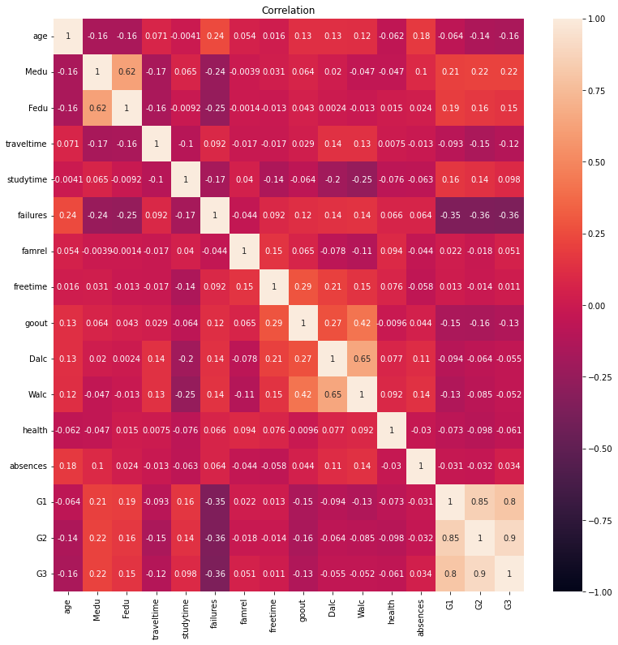

```python
# calculating correlation matrix
corr = data.corr()

# creating a heatmap of the correlation matrix
plt.figure(figsize = (13,13))
c = sns.heatmap(corr, annot=True, vmin=-1, vmax=1)
plt.title('Correlation')
plt.show()
```

## Modeling

Now that we've explored our data a bit more, let's test to see if our assumptions or hypotheses were correct!  
It's important to actually back up your claims, so we'll some modeling techniques that will give us some more  
quantitative evidence about if these relationships and trends actually exist in the data!

First, we will import the necessary packages for many ML models.

```python
# Standard ML Models for comparison
from sklearn.linear_model import LinearRegression
from sklearn.ensemble import RandomForestRegressor
from sklearn.svm import SVR
from sklearn import tree

# Splitting data into training/testing
from sklearn.model_selection import train_test_split
from sklearn.preprocessing import MinMaxScaler

# Metrics
from sklearn.metrics import mean_squared_error, mean_absolute_error, median_absolute_error

# Distributions
import scipy
```

### Linear Regression

We'll start out by doing some linear regression, which is one of the most commonly used types of modeling!

First, we need to split our data up into a training set and a testing set to evaluate our model!

```python
# splitting the data
X = data[['studytime', 'failures', 'higher', 'paid']]   # only using the features we explored earlier
y = data['G3']   # only looking at predicting the final grade
X_train, X_test, y_train, y_test = train_test_split(X, y, test_size = 0.25, random_state=42)
```

Now we can train the data using the linear regression model!

```python
model = LinearRegression()
# model.fit(X_train, y_train)
```

When I tried to fit the model, I got an error saying that there was a failure to convert to float from string "yes".  
This issue comes from the fact that we still have categorical values in our data, so we will need to address it first!  
Since we only have two variables here that are causing the issue ("higher" and "paid"), I will just manually  
encode these columns using a 0 to represent a "no" and a 1 to represent a "yes". This is a simple version of one  
hot encoding in which we use binary values to represent the categories of a categorical variable. Note: this works when  
the variable has few categories like in our case, but if there are too many this becomes a very inefficient  
approach.

**One Hot Encoding**

```python
# using python map function to convert yes/no to 1/0
data['paid'] = data['paid'].map(dict(yes=1.0, no=0.0))
data['higher'] = data['higher'].map(dict(yes=1.0, no=0.0))
```

```python
display(data[['paid','higher']])
```

|  | paid | higher |
| --- | --- | --- |
| 0 | 0.0 | 1.0 |
| 1 | 0.0 | 1.0 |
| 2 | 1.0 | 1.0 |
| 3 | 1.0 | 1.0 |
| 4 | 1.0 | 1.0 |
| ... | ... | ... |
| 390 | 1.0 | 1.0 |
| 391 | 0.0 | 1.0 |
| 392 | 0.0 | 1.0 |
| 393 | 0.0 | 1.0 |
| 394 | 0.0 | 1.0 |

395 rows × 2 columns

Now that we've fixed this issue let's try fitting our model again!

```python
# splitting the data
X = data[['studytime', 'failures', 'higher', 'paid']]   # only using the features we explored earlier
y = data['G3']   # only looking at predicting the final grade
X_train, X_test, y_train, y_test = train_test_split(X, y, test_size=0.3, random_state=42)
```

```python
model = LinearRegression()
model.fit(X_train, y_train)
```

```
LinearRegression()
```

No more error! Now we can use the model to predict the final grades of the students!

```python
predictions = model.predict(X_test)

slope = model.coef_
intercept = model.intercept_

def myfunc(y_test):
    return slope*y_test+intercept
mymodel = list(map(myfunc,y_test))
```

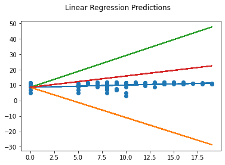

```python
# plotting the predictions
fig = plt.figure()
plt.scatter(y_test,predictions)
plt.plot(y_test,mymodel)
fig.suptitle('Linear Regression Predictions')
```

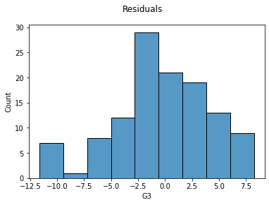

```python
fig = plt.figure()
sns.histplot((y_test-predictions))
fig.suptitle('Residuals')
```

Just at a glance, it doesn't seem like our linear regression results were all that great, since we can't see  
much of a trend in the resulting graph. However, let's take a look at some actual metrics to see how our model did.

```python
from sklearn import metrics
from sklearn.metrics import r2_score

print('MAE:', metrics.mean_absolute_error(y_test, predictions))
print('MSE:', metrics.mean_squared_error(y_test, predictions))
print('RMSE:', np.sqrt(metrics.mean_squared_error(y_test, predictions)))
print("Explain variance score =", round(metrics.explained_variance_score(y_test, predictions), 2))
print('r2 Score:', r2_score(y_test, predictions))
```

```
MAE: 3.5560358128799874
MSE: 20.425151744322537
RMSE: 4.519419403454667
Explain variance score = 0.07
r2 Score: 0.07082645700652956
```

We can see that we have a very large mean squared error. This is because this metric is extra vulnerable to outliers,  
and in this case we have a large amount of them since we have a significant number of 0 grades. Also, our  
rsquared score was also quite low with an ideal being 1.0. Let's try a different model! Or perhaps we might need  
to use some different variables with higher correlations.

To do the latter, just be looking at the correlation heatmap from earlier, we can see that G1 and G2 are highly  
correlated with the final grade. So, to show how linear regression can work, we can easily make it perform better  
by including these columns in our test data. However, since we already know the grades to be highly correlated, it will  
not provide much useful insight.

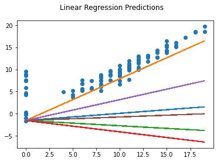

```python
X = data[['G1', 'G2', 'studytime', 'failures', 'higher', 'paid']]
y = data['G3']
X_train, X_test, y_train, y_test = train_test_split(X, y, test_size=0.3)

model = LinearRegression()
model.fit(X_train, y_train)

predictions = model.predict(X_test)

slope = model.coef_
intercept = model.intercept_

def myfunc(y_test):
    return slope*y_test+intercept
mymodel = list(map(myfunc,y_test))

# plotting the predictions
fig = plt.figure()
plt.scatter(y_test,predictions)
plt.plot(y_test,mymodel)
fig.suptitle('Linear Regression Predictions')
```

```python
print('MAE:', metrics.mean_absolute_error(y_test, predictions))
print('MSE:', metrics.mean_squared_error(y_test, predictions))
print('RMSE:', np.sqrt(metrics.mean_squared_error(y_test, predictions)))
print("Explain variance score =", round(metrics.explained_variance_score(y_test, predictions), 2))
print('r2 Score:', r2_score(y_test, predictions))
```

```
MAE: 1.371721766928919
MSE: 6.124084883711269
RMSE: 2.474688845837244
Explain variance score = 0.74
r2 Score: 0.7390623013003224
```

As you can see, just by including the first and second period grades, we have increased the accuracy of our model  
greatly. Clearly these two attributes have a close relationship, but again they are not that useful to us in our  
exploration of this data.

Given that the outliers of the 0 grades seem to be hurting our models, let's try excluding them.

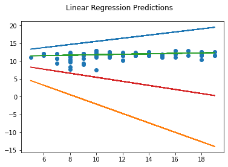

```python
no_zero_data = data[data['G3'] != 0]

# doing linear regression without G1, G2

X = no_zero_data[['studytime', 'failures', 'higher', 'paid']]
y = no_zero_data['G3']
X_train, X_test, y_train, y_test = train_test_split(X, y, test_size=0.3)

model = LinearRegression()
model.fit(X_train, y_train)

predictions = model.predict(X_test)

slope = model.coef_
intercept = model.intercept_

def myfunc(y_test):
    return slope*y_test+intercept
mymodel = list(map(myfunc,y_test))

# plotting the predictions
fig = plt.figure()
plt.scatter(y_test,predictions)
plt.plot(y_test,mymodel)
fig.suptitle('Linear Regression Predictions')
```

```python
print('MAE:', metrics.mean_absolute_error(y_test, predictions))
print('MSE:', metrics.mean_squared_error(y_test, predictions))
print('RMSE:', np.sqrt(metrics.mean_squared_error(y_test, predictions)))
print("Explain variance score =", round(metrics.explained_variance_score(y_test, predictions), 2))
print('r2 Score:', r2_score(y_test, predictions))
```

```
MAE: 2.6312577003764828
MSE: 10.479422569989287
RMSE: 3.2371936256562237
Explain variance score = 0.09
r2 Score: 0.08735106243994994
```

Well, that didn't work...the rsquared value is now almost zero which means that this model doesn't explain any of  
the variance in the response variable at all (the mean would predict just as well as this model).

**What if we include all of the features?** (Excluding G1, G2)

To do this we must address all of the categorical variables using one hot encoding. So I will use the pandas function  
get_dummies to do this on all of these attributes.

```python
data = data.drop(['school', 'G1', 'G2'], axis='columns')   # dropping school and first/second period grades
data = pd.get_dummies(data)
data.head()
```

|  | age | Medu | Fedu | traveltime | studytime | failures | paid | higher | famrel | freetime | ... | famsup_no | famsup_yes | activities_no | activities_yes | nursery_no | nursery_yes | internet_no | internet_yes | romantic_no | romantic_yes |
| --- | --- | --- | --- | --- | --- | --- | --- | --- | --- | --- | --- | --- | --- | --- | --- | --- | --- | --- | --- | --- | --- |
| 0 | 18 | 4 | 4 | 2 | 2 | 0 | 0.0 | 1.0 | 4 | 3 | ... | 1 | 0 | 1 | 0 | 0 | 1 | 1 | 0 | 1 | 0 |
| 1 | 17 | 1 | 1 | 1 | 2 | 0 | 0.0 | 1.0 | 5 | 3 | ... | 0 | 1 | 1 | 0 | 1 | 0 | 0 | 1 | 1 | 0 |
| 2 | 15 | 1 | 1 | 1 | 2 | 3 | 1.0 | 1.0 | 4 | 3 | ... | 1 | 0 | 1 | 0 | 0 | 1 | 0 | 1 | 1 | 0 |
| 3 | 15 | 4 | 2 | 1 | 3 | 0 | 1.0 | 1.0 | 3 | 2 | ... | 0 | 1 | 0 | 1 | 0 | 1 | 0 | 1 | 0 | 1 |
| 4 | 16 | 3 | 3 | 1 | 2 | 0 | 1.0 | 1.0 | 4 | 3 | ... | 0 | 1 | 1 | 0 | 0 | 1 | 1 | 0 | 1 | 0 |

5 rows × 53 columns

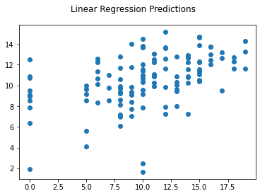

```python
X = data
y = data['G3']
X_train, X_test, y_train, y_test = train_test_split(X, y, test_size = 0.3, random_state=42)

X_train = X_train.drop('G3', axis='columns')
X_test = X_test.drop('G3', axis='columns')

model = LinearRegression()
model.fit(X_train, y_train)

predictions = model.predict(X_test)

slope = model.coef_
intercept = model.intercept_

def myfunc(y_test):
    return slope*y_test+intercept
mymodel = list(map(myfunc,y_test))

# plotting the predictions
fig = plt.figure()
plt.scatter(y_test,predictions)
# plt.plot(y_test,mymodel)
fig.suptitle('Linear Regression Predictions')
```

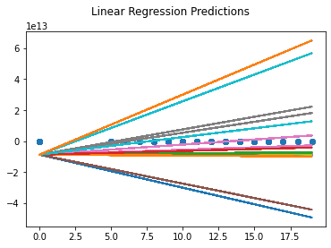

```python
# plotting the predictions
fig = plt.figure()
plt.scatter(y_test,predictions)
plt.plot(y_test,mymodel)
fig.suptitle('Linear Regression Predictions')
```

```python
print('MAE:', metrics.mean_absolute_error(y_test, predictions))
print('MSE:', metrics.mean_squared_error(y_test, predictions))
print('RMSE:', np.sqrt(metrics.mean_squared_error(y_test, predictions)))
print("Explain variance score =", round(metrics.explained_variance_score(y_test, predictions), 2))
print('r2 Score:', r2_score(y_test, predictions))
```

```
MAE: 3.281898306197479
MSE: 17.65902321278548
RMSE: 4.202264057955602
Explain variance score = 0.2
r2 Score: 0.1966621658520239
```

Including all of our variables seems to have improved our model quite a bit, with the rsquared score now around 0.2,  
which is still pretty bad. So let's try some other kinds of models!

### Decision Tree

A decision tree classifier predicts a target variable by learning decision rules from various features in the data.

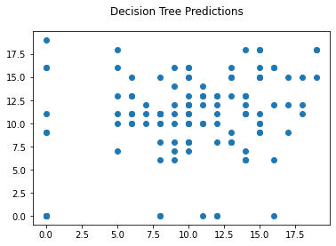

```python
X = data
y = data['G3']
X_train, X_test, y_train, y_test = train_test_split(X, y, test_size = 0.3, random_state=42)

X_train = X_train.drop('G3', axis='columns')
X_test = X_test.drop('G3', axis='columns')

model = tree.DecisionTreeClassifier()
model.fit(X_train, y_train)

predictions = model.predict(X_test)

# plotting the predictions
fig = plt.figure()
plt.scatter(y_test,predictions)
# plt.plot(y_test,mymodel)
fig.suptitle('Decision Tree Predictions')
```

```python
print('MAE:', metrics.mean_absolute_error(y_test, predictions))
print('MSE:', metrics.mean_squared_error(y_test, predictions))
print('RMSE:', np.sqrt(metrics.mean_squared_error(y_test, predictions)))
print("Explain variance score =", round(metrics.explained_variance_score(y_test, predictions), 2))
print('r2 Score:', r2_score(y_test, predictions))
```

```
MAE: 3.097731092436976
MSE: 14.909851260504205
RMSE: 3.861327655160101
Explain variance score = 0.33
r2 Score: 0.3217264921872991
```

This seems to work better than our linear regression! With a score of 0.32 as opposed to 0.2.

### Random Forest

A random forest is a an ensemble of many decision trees, which each make a prediction.

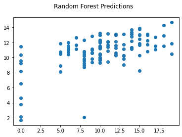

```python
X = data
y = data['G3']
X_train, X_test, y_train, y_test = train_test_split(X, y, test_size = 0.3, random_state=42)

X_train = X_train.drop('G3', axis='columns')
X_test = X_test.drop('G3', axis='columns')

model = RandomForestRegressor()
model.fit(X_train, y_train)

predictions = model.predict(X_test)

# plotting the predictions
fig = plt.figure()
plt.scatter(y_test,predictions)
# plt.plot(y_test,mymodel)
fig.suptitle('Random Forest Predictions')
```

```python
print('MAE:', metrics.mean_absolute_error(y_test, predictions))
print('MSE:', metrics.mean_squared_error(y_test, predictions))
print('RMSE:', np.sqrt(metrics.mean_squared_error(y_test, predictions)))
print("Explain variance score =", round(metrics.explained_variance_score(y_test, predictions), 2))
print('r2 Score:', r2_score(y_test, predictions))
```

```
MAE: 3.041008403361345
MSE: 14.848347899159664
RMSE: 3.8533554078438788
Explain variance score = 0.34
r2 Score: 0.32452438063786593
```

This works even better than the single decision tree, although only by slightly.

### Support Vector Regression

Support vector machines predict by drawing lines between cluster of data to group them into classes

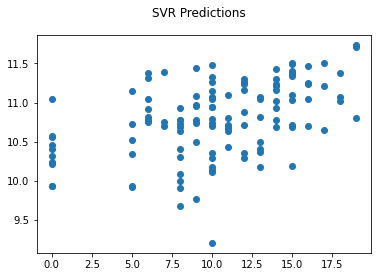

```python
X = data
y = data['G3']
X_train, X_test, y_train, y_test = train_test_split(X, y, test_size = 0.3, random_state=42)

X_train = X_train.drop('G3', axis='columns')
X_test = X_test.drop('G3', axis='columns')

model = SVR()
model.fit(X_train, y_train)

predictions = model.predict(X_test)

# plotting the predictions
fig = plt.figure()
plt.scatter(y_test,predictions)
# plt.plot(y_test,mymodel)
fig.suptitle('SVR Predictions')
```

```python
print('MAE:', metrics.mean_absolute_error(y_test, predictions))
print('MSE:', metrics.mean_squared_error(y_test, predictions))
print('RMSE:', np.sqrt(metrics.mean_squared_error(y_test, predictions)))
print("Explain variance score =", round(metrics.explained_variance_score(y_test, predictions), 2))
print('r2 Score:', r2_score(y_test, predictions))
```

```
MAE: 3.5411626084405388
MSE: 20.351284506858676
RMSE: 4.511239797091114
Explain variance score = 0.08
r2 Score: 0.0741867983936878
```

Not very good, we are getting a very low rsquared score again.

**Model Performance**

Of the models we used, random forest regression had the best performance, followed very closely by decision trees.  
However, overall the results from our data weren't that great, with the highest rsquared score being only around 0.33

## Conclusion & Insights

**Insights**

Overall, we didn't gain that many conclusive insights. From our data exploration, it seems like many of the features  
can have a significant influence on a student's final grades. For example, past failures seemed to make students  
get worse grades, and paid extra classes seemed to improve their final grades. However, when we performed  
various types of prediction model tests we didn't get very significant results. Our best model only had an rsquared  
score of 0.33 which means it doesn't predict the final grade of a student based on the features very well. Although,  
when we included the first and second period grades "G1" and "G2", we got quite good predictions. Like mentioned  
before however, this isn't that useful for us since presumably we already know the fact that final  
grades are based on first and second period grades.

**Possible Mistakes & How to Improve**

I think there are several possible explanations for the poor performance of our models on this data. First, the  
first thing that stands out to me is the number of outliers in our data. There was a significant number of 0  
grade values that definitely didn't follow the overall distribution of grades. This definitely hurt our models,  
evident by the extremely high mean squared error values we got (up to 20 in some cases). This metric magnifies  
large errors in our data, and I assume this mostly comes from the students that failed and scored 0 on their final  
grade. To improve upon this we should take measures to either remove outliers or use models that are less vulnerable  
to them.

Another way I think we could improve is simply by trying other types of classification techniques. We tried several  
types but there are other models that may have worked better.

**Conclusion**

In conclusion, I still believe that the attributes in this dataset do have some influence on a student's final grade.  
However, without knowing their first and second period scores, it is hard to predict their final grade with  
good accuracy. Either we need more data to see a significant trend, or there is just too much variation in a student's  
performance to predict their final grade without knowing their previous scores.

Looks like anyone can get good (or bad) grades in school! Although it might still be helpful to study more and  
pay for extra classes outside of school...

[figure not shown]

## Sources

- Kaggle.com: https://www.kaggle.com/datasets/dipam7/student-grade-prediction?resource=download
- Dataset from UCL Machine Learning Repository: https://archive.ics.uci.edu/ml/datasets/student+performance
- Paulo Cortez, University of Minho, GuimarÃ£es, Portugal, http://www3.dsi.uminho.pt/pcortez
- Classification Methods: https://stackabuse.com/overview-of-classification-methods-in-python-with-scikit-learn/